# Rapport - Statistiques

ESPANA GUTIERREZ Pablo, MULOT Lendy

08/03/2020

### Introduction

Nous avons choisi de nous intéresser aux données du gouvernement français sur les émissions de polluants des véhicules commercialisés en France en 2014 (cf. Bibliographie). Nous avons décidé pour mener nos expériences, de ne pas considérer les voitures de la marque Mercedes car elles étaient surreprésentées (87% des voitures de notre jeu de données) et pourraient donc introduire un biais.

```r
t2014 <- read.csv("2014.csv", header=T, sep=";", dec=",")

t <- t2014 %>%
  filter(lib_mrq != "MERCEDES")

head(t)
```

```
##      lib_mrq lib_mod_doss lib_mod                dscom            cnit
## 1 ALFA-ROMEO          159     159 159 1750 Tbi (200ch) M10ALFVP000G340
## 2 ALFA-ROMEO          159     159 159 1750 Tbi (200ch) M10ALFVP000H341
## 3 ALFA-ROMEO          159     159 159 2.0 JTDm (136ch) M10ALFVP000E302
## 4 ALFA-ROMEO          159     159 159 2.0 JTDm (136ch) M10ALFVP000F303
## 5 ALFA-ROMEO          159     159 159 2.0 JTDm (170ch) M10ALFVP000G304
## 6 ALFA-ROMEO          159     159 159 2.0 JTDm (170ch) M10ALFVP000H305
##           tvv cod_cbr hybride puiss_admin_98 puiss_max typ_boite_nb_rapp
## 1 939AXN1B52C      ES     non             12       147               M 6
## 2 939BXN1B53C      ES     non             12       147               M 6
## 3  939AXR1B64      GO     non              7       100               M 6
## 4 939AXR1B64B      GO     non              7       100               M 6
## 5  939AXS1B66      GO     non              9       125               M 6
## 6 939AXS1B66B      GO     non              9       125               M 6
##   conso_urb conso_exurb conso_mixte co2 co_typ_1    hc   nox hcnox  ptcl
```

[output cut: 20 more lines]

```r
length(t)
```

```
## [1] 30
```

Sur cette thématique, nous allons chercher à répondre aux deux questions suivantes :

- La masse d’une voiture est-elle corrélée à sa consommation ?
- Peut-on considérer que les voitures de gamme luxueuse rejettent autant de $CO_2$ que les voitures de gamme inférieure ?

### I) Corrélation entre la masse et la consommation d’une voiture

Les données que nous utilisons nous donnent la possibilité de considérer plusieurs types de consommation :

- Urbaine
- Extra urbaine
- Mixte

Cependant, nous nous sommes intéressés à la consommation extra urbaine, qui nous paraissait plus pertinente.

Nous cherchons donc à comparer deux séries de données quantitatives, donc nous avons utilisé un test de corrélation, ayant pour hypothèse $H_0$ que les deux séries sont décorrélées.

```r
cor.test(t$conso_exurb, t$masse_ordma_max)
```

```
##
##  Pearson's product-moment correlation
##
## data:  t$conso_exurb and t$masse_ordma_max
## t = 151.79, df = 18781, p-value < 2.2e-16
## alternative hypothesis: true correlation is not equal to 0
## 95 percent confidence interval:
##  0.7357561 0.7486019
## sample estimates:
##       cor
## 0.7422472
```

On trouve une p-valeur inférieure à $2.2 \times 10^{-16}$, donc au risque $\alpha = 5\%$, nous pouvons rejeter l’hypothèse $H_0$.

Nous pouvons ainsi conclure (au risque $\alpha = 5\%$) que la masse de la voiture est corrélée à sa consommation extra urbaine.

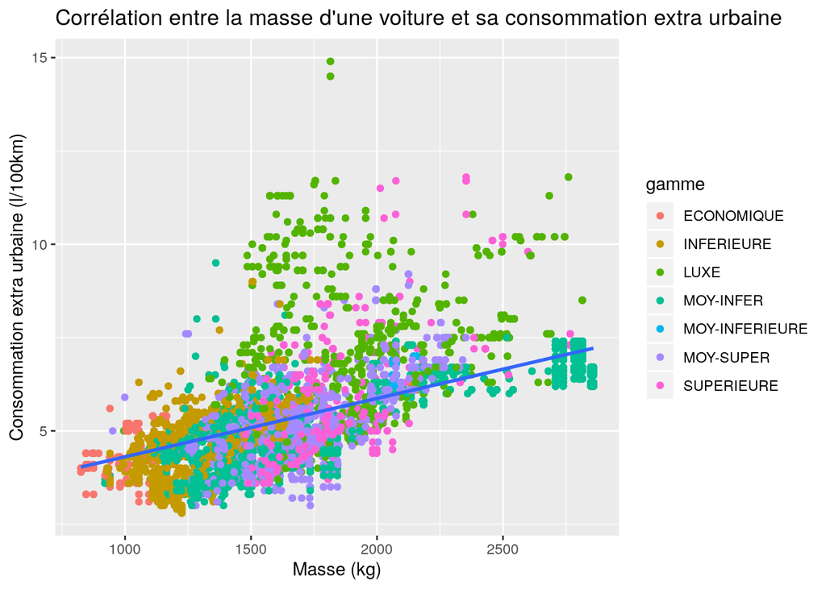

```r
gg <- ggplot(t, aes(x=masse_ordma_max, y=conso_exurb)) + geom_point(aes(col=gamme)) +
  geom_smooth(method="lm") +
  labs(title="Corrélation entre la masse d'une voiture et sa consommation extra urbaine") +
  xlab("Masse (kg)") + ylab("Consommation extra urbaine (l/100km)")
plot(gg)
```

Sur le graphique ci-dessus, on remarque que les voitures de gamme économique et inférieure semblent consommer moins que celles de luxe, d’où la pertinence de la seconde question.

### II) Comparaison du rejet de $CO_2$ pour différentes gammes

À la vue du graphique ci-dessus, nous avons choisi de comparer la gamme luxueuse à la gamme inférieure puisque c’est pour ces deux gammes que les différences semblent être les plus notables.

```r
tinf <- t %>%
  filter(gamme == "INFERIEURE")

tluxe <- t %>%
  filter(gamme == "LUXE")

t2 <- t %>%
  filter(gamme == "LUXE" | gamme == "INFERIEURE")

head(t2)
```

```
##      lib_mrq lib_mod_doss   lib_mod                         dscom
## 1 ALFA-ROMEO           4C        4C                            4C
## 2 ALFA-ROMEO  AR8C SPIDER 8C SPIDER                     8C SPIDER
## 3 ALFA-ROMEO  AR8C SPIDER 8C SPIDER                     8C SPIDER
## 4 ALFA-ROMEO         MITO      MITO MITO 0.9 Twin Air (105ch) S/S
## 5 ALFA-ROMEO         MITO      MITO MITO 0.9 Twin Air (105ch) S/S
## 6 ALFA-ROMEO         MITO      MITO MITO 0.9 Twin Air (105ch) S/S
##              cnit         tvv cod_cbr hybride puiss_admin_98 puiss_max
## 1 M10ALFVP000S413  960CXB1A01      ES     non             14     177.0
## 2 M10ALFVP0005293 920BXA1A00B      ES     non             38     331.0
## 3 M10ALFVP0006039  920BXA1A00      ES     non             38     331.0
## 4 M10ALFVP000J379  955AXY1B18      ES     non              5      77.0
## 5 M10ALFVP000K380 955AXY1B18B      ES     non              5      77.0
## 6 M10ALFVP000U451  955AXZ1B21      ES     non              5      73.5
##   typ_boite_nb_rapp conso_urb conso_exurb conso_mixte co2 co_typ_1    hc   nox
```

[output cut: 20 more lines]

```r
length(t2)
```

```
## [1] 30
```

Nous cherchons donc à relier la gamme, une donnée qualitative, au rejet de $CO_2$, une donnée quantitative. Nous allons donc mener un test de comparaison de moyenne entre les données des deux gammes.

Pour bien choisir le test, nous devons déjà vérifier si les données suivent une loi normale. Pour cela, nous avons utilisé un test de Shapiro, ayant pour hypothèse $H_0$ que les données suivent une loi normale.

```r
shapiro.test(tinf$co2)
```

```
##
##  Shapiro-Wilk normality test
##
## data:  tinf$co2
## W = 0.97684, p-value = 5.787e-12
```

```r
shapiro.test(tluxe$co2)
```

```
##
##  Shapiro-Wilk normality test
##
## data:  tluxe$co2
## W = 0.94416, p-value < 2.2e-16
```

Dans les deux cas, la p-valeur est inférieure à un risque $\alpha = 5\%$. On peut donc rejeter l’hypothèse de normalité.

Nous allons ainsi mener un test non paramétrique de Wilcoxon, ayant pour hypothèse $H_0$ que les moyennes des deux séries peuvent être considerées comme identiques, c’est-à-dire que la différence peut s’expliquer simplement avec les fluctuations d’échantillonage.

```r
wilcox.test(tinf$co2, tluxe$co2)
```

```
##
##  Wilcoxon rank sum test with continuity correction
##
## data:  tinf$co2 and tluxe$co2
## W = 85238, p-value < 2.2e-16
## alternative hypothesis: true location shift is not equal to 0
```

On obtient ici aussi une p-valeur inférieure à $2.2 \times 10^{-16}$, donc pour un risque $\alpha = 5\%$ on peut rejeter $H_0$.

Nous pouvons donc conclure (au risque $\alpha = 5\%$) que les voitures de luxe et les voitures de gammes inférieures ne consomment en moyenne pas autant.

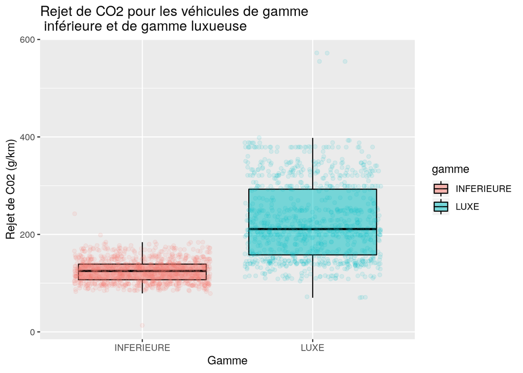

```r
gg <- ggplot(t2, aes(x=gamme, y=co2, fill=gamme, colour=gamme)) +
  geom_boxplot(alpha=0.5, outlier.alpha=0, colour="black") +
  geom_jitter(fill="black", alpha = 0.1)  +
  labs(title="Rejet de CO2 pour les véhicules de gamme\n inférieure et de gamme luxueuse") +
  xlab("Gamme") + ylab("Rejet de C02 (g/km)")
plot(gg)
```

À la vue de nos résultats et du graphique ci-dessus, nous pouvons extrapoler que les voitures de luxe consomment en moyenne plus que les voitures de gamme inférieure, malgré une plus grande dispersion pour les voitures de luxe.

### Conclusion

Nous avons pu répondre à la question de la corrélation entre masse et consommation à l’aide d’un test de corrélation, qui nous a révélé, au risque $\alpha = 5\%$, que ces deux paramètres sont effectivement corrélés.

À l’aide d’un test de Wilcoxon et en extrapolant le graphique associé, nous avons aussi conclu que les voitures de gammes inférieures consomment en moyenne moins que celles de gamme luxueuse.

Il ne faut cependant pas oublier que d’autres paramètres peuvent entrer en jeu, et que les liens ne sont pas nécéssairement des liens de cause à effet.

### Bibliographie

[Les données utilisées (cliquez pour ouvrir).](https://www.data.gouv.fr/fr/datasets/emissions-de-co2-et-de-polluants-des-vehicules-commercialises-en-france/)